# Importation des librairies

```python
import pandas as pd
import numpy as np
import matplotlib.pyplot as plt
from sklearn.model_selection import train_test_split, GridSearchCV, RandomizedSearchCV
from sklearn.preprocessing import LabelEncoder, OrdinalEncoder
from sklearn.tree import DecisionTreeClassifier
from sklearn.metrics import f1_score, confusion_matrix, classification_report, accuracy_score
import joblib
```

# Importation des données de survie

```python
data = pd.read_csv("dead_survie.csv", sep=";")
```

```python
data.head()
```

|  | sex | age | country | province | city | infection_case | confirmed_date | state |
| --- | --- | --- | --- | --- | --- | --- | --- | --- |
| 0 | male | 50s | Korea | Seoul | Gangseo-gu | overseas inflow | 2020-01-23 | released |
| 1 | male | 30s | Korea | Seoul | Jungnang-gu | overseas inflow | 2020-01-30 | released |
| 2 | male | 50s | Korea | Seoul | Jongno-gu | contact with patient | 2020-01-30 | released |
| 3 | male | 20s | Korea | Seoul | Mapo-gu | overseas inflow | 2020-01-30 | released |
| 4 | female | 20s | Korea | Seoul | Seongbuk-gu | contact with patient | 2020-01-31 | released |

# Encodage des données

Encodage des variables de notre dataset via LabelEncoder()

```python
encoder = LabelEncoder()
for col in data.columns:
    data[col] = encoder.fit_transform(data[col])
```

### Explication des valeurs importantes encodées :

- released : 2
- deceaded : 0
- isolated : 1

# Définition de nos données d'entrainement et de test

Répartition des données du dataset dans un Trainset et un Testset, de façon aléatoire et avec 20% des données dans le Testset. Cela est fait en sachant nos variables explicatives seront contenues dans les X, tandis que les variables cibles seront dans les y.

L'absence de la variable 'country' dans cette initialisation est dûe au fait qu'elle a été supprimé du fait qu'elle soit peu importante. Cela est expliqué dans le deuxième modèle.

```python
features = ['sex','province','city','confirmed_date','age','infection_case']
X = data[features]
y = data['state']
X_train, X_test, y_train, y_test = train_test_split(X, y, test_size = 0.2, random_state=0)
```

Vérification de la bonne répartition du dataset dans les sous ensembles train et test.

```python
print('Taille train set : ',X_train.shape)
print('Taille test set : ',X_test.shape)
```

```
('Taille train set : ', (1994, 6))
('Taille test set : ', (499, 6))
```

# Création du modèle

On essaie de prédire si une personne, en fonction de certaines variables (sexe, âge, cause de l'infection), survit ou non au Covid19. Cela implique donc que nous sommes dans un problème de prédiction avec une variable cible qualitative. On utilisera un arbre de décision.

```python
modele = DecisionTreeClassifier(random_state=0)
```

Le random_state = 0 est utile pour optimiser la répétabilité de nos résultats, afin de permettre d'évaluer les équitablement les décisions de notre arbre. (Il est utilisé dans les deux premiers tests et on remarque à partir du troisième que lorsque nous ne l'initialisons pas dans notre modèle, ce dernier nous fournit de meilleur resultats par rapport à la prédiction de décès.)

# Evaluation du modele

On utilisera dans cette partie le score F1, qui nous permet de mesurer les proportion d'erreurs de type 1 et 2 et qui est la moyenne pondérée de la précision et du rappel. On visualisera également le rapport faux positif et faux négatif dans une matrice de confusion qui permet ainsi de mesurer les performances de notre modele en vérifiant à quelle fréquence ses prédictions sont exactes par rapport à la réalité.

Nous aurons donc les informations sur la précision et le rappel, qui sont respectivement la proportion des items pertinents parmi l'ensemble des items proposés, et la proportion des items pertinents proposés parmi l'ensemble des items pertinents.

```python
def evaluation(modele):

    modele.fit(X_train, y_train)
    Predict = modele.predict(X_test)

    print(confusion_matrix(y_test, Predict))
    print(classification_report(y_test, Predict))
```

### Explication de la fonction :

On commence par entrainer notre modele avec les données d'entrainement, puis avec Predict on fait des prédictions sur notre X_test. Les résultats observés seront ensuite affichés dans une matrice de confusion et de manière générale dans un tableau de résultats où nous pourrons observer la précision de nos résulats.

# Premier modèle

```python
evaluation(modele)
```

```
[[  1   4   2]
 [  3 188  49]
 [  2  43 207]]
             precision    recall  f1-score   support

          0       0.17      0.14      0.15         7
          1       0.80      0.78      0.79       240
          2       0.80      0.82      0.81       252

avg / total       0.79      0.79      0.79       499
```

### Explications des résultats :

Notre modèle en l'état ne nous permet pas vraiment de prédire si une personne décède du Covid19. On va donc ajuster certains paramètres afin d'optimiser nos résultats.

## Variables importantes

```
Text(0.5,1,u'Visualisation des variables les plus importantes pour ce mod\xe8le (Test 1)')
```

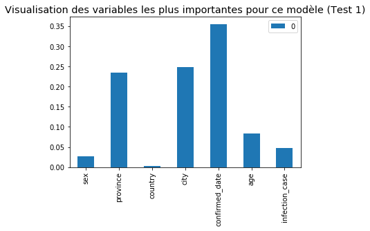

```python
pd.DataFrame(modele.feature_importances_, index=X_train.columns).plot.bar()
plt.title(u'Visualisation des variables les plus importantes pour ce modèle (Test 1)', size = 'x-large')
```

# Deuxième modèle

```python
evaluation(modele)
```

```
[[  1   4   2]
 [  2 190  48]
 [  2  41 209]]
             precision    recall  f1-score   support

          0       0.20      0.14      0.17         7
          1       0.81      0.79      0.80       240
          2       0.81      0.83      0.82       252

avg / total       0.80      0.80      0.80       499
```

### Explication des résultats :

Le fait d'enlever le pays joue donc un rôle dans l'amélioration de nos résultats.

## Variables importantes

```
Text(0.5,1,u'Visualisation des variables les plus importantes pour ce mod\xe8le (Test 2)')
```

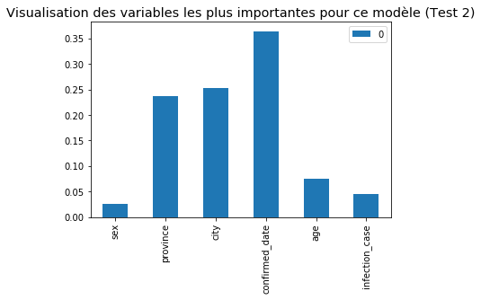

```python
pd.DataFrame(modele.feature_importances_, index=X_train.columns).plot.bar()
plt.title(u'Visualisation des variables les plus importantes pour ce modèle (Test 2)', size = 'x-large')
```

### Explications :

Du fait de l'amélioration de nos résultats avec ces variables, nous les garderons dans la suite du calibrage de notre modèle. Cette calibration se ferait grâce aux paramètres optimaux, qui seront donnés avec la librairie GridSearchCV.

# Troisième modèle

## Recherche des paramètres optimaux

```python
params = {'criterion':['gini', 'entropy'],'splitter' : ['best','random'],'max_leaf_nodes': list(range(2, 100)), 'min_samples_split': [2, 3, 4]}
grid_search_cv = GridSearchCV(DecisionTreeClassifier(random_state=15), params, cv=5)
grid_search_cv.fit(X_train, y_train)
```

```
GridSearchCV(cv=5, error_score='raise',
       estimator=DecisionTreeClassifier(class_weight=None, criterion='gini', max_depth=None,
            max_features=None, max_leaf_nodes=None,
            min_impurity_decrease=0.0, min_impurity_split=None,
            min_samples_leaf=1, min_samples_split=2,
            min_weight_fraction_leaf=0.0, presort=False, random_state=15,
            splitter='best'),
       fit_params=None, iid=True, n_jobs=1,
       param_grid={'min_samples_split': [2, 3, 4], 'splitter': ['best', 'random'], 'criterion': ['gini', 'entropy'], 'max_leaf_nodes': [2, 3, 4, 5, 6, 7, 8, 9, 10, 11, 12, 13, 14, 15, 16, 17, 18, 19, 20, 21, 22, 23, 24, 25, 26, 27, 28, 29, 30, 31, 32, 33, 34, 35, 36, 37, 38, 39, 40, 41, 42, 43, 44, …
       pre_dispatch='2*n_jobs', refit=True, return_train_score='warn',
       scoring=None, verbose=0)
```

## Evaluation

```python
evaluation(grid_search_cv.best_estimator_)
```

```
[[  1   3   3]
 [  2 181  57]
 [  0  28 224]]
             precision    recall  f1-score   support

          0       0.33      0.14      0.20         7
          1       0.85      0.75      0.80       240
          2       0.79      0.89      0.84       252

avg / total       0.81      0.81      0.81       499
```

# Quatrième modèle

## Recherche des paramètres optimaux

```python
Random_grid = RandomizedSearchCV(DecisionTreeClassifier(random_state=15), params, cv=4)
Random_grid.fit(X_train, y_train)
```

```
RandomizedSearchCV(cv=4, error_score='raise',
          estimator=DecisionTreeClassifier(class_weight=None, criterion='gini', max_depth=None,
            max_features=None, max_leaf_nodes=None,
            min_impurity_decrease=0.0, min_impurity_split=None,
            min_samples_leaf=1, min_samples_split=2,
            min_weight_fraction_leaf=0.0, presort=False, random_state=15,
            splitter='best'),
          fit_params=None, iid=True, n_iter=10, n_jobs=1,
          param_distributions={'min_samples_split': [2, 3, 4], 'splitter': ['best', 'random'], 'criterion': ['gini', 'entropy'], 'max_leaf_nodes': [2, 3, 4, 5, 6, 7, 8, 9, 10, 11, 12, 13, 14, 15, 16, 17, 18, 19, 20, 21, 22, 23, 24, 25, 26, 27, 28, 29, 30, 31, 32, 33, 34, 35, 36, 37, 38, 39, 40, 41, …
          pre_dispatch='2*n_jobs', random_state=None, refit=True,
          return_train_score='warn', scoring=None, verbose=0)
```

## Evaluation

```python
evaluation(Random_grid.best_estimator_)
```

```
[[  0   3   4]
 [  1 193  46]
 [  1  33 218]]
             precision    recall  f1-score   support

          0       0.00      0.00      0.00         7
          1       0.84      0.80      0.82       240
          2       0.81      0.87      0.84       252

avg / total       0.82      0.82      0.82       499
```

### Explications :

On arrive dans une situation où notre modèle ne réussit plus à faire de prédiction sur le nombre de mort, néanmoins on améliore parallèlement les résultats de prédiction sur les personnes hospitalisées et sorties (guéries). Notre modèle est donc en mesure de manière assez exacte, l'état d'une personne hospitalisée et guerie.

# Conclusion

Notre modèle sera plus performant concernant la prédiction de la mort d'un patient avec plus de données relatives à cet état, toute fois ses performances dans la prédiction d'une personne hospitalisée ou guérie. Avec le calibrage des paramètres on est passé d'une moyenne de précision de 79% à 82%. Nous avons également remarqué que le choix des bonnes variables a aussi une importance dans l'amélioration des prédictions du modèle.

# Sauvegarde du modèle :

Opérations de sauvegarde du modèle afin de pouvoir le tester ailleurs

```python
filename = 'modele81.sav'
filename1 = 'modele82.sav'
joblib.dump(grid_search_cv.best_estimator_, filename)
joblib.dump(Random_grid.best_estimator_, filename1)
```

```
['modele82.sav']
```

#### Auteurs :

Rédigé par Daniel ATANGANA, en collaboration avec :

- BUISSON-CHAVOT Julien
- CHATRY Roxane
- GORRICHON Nahia
- VIRGAUX Pierre

#### Contexte : Etude statistique sur le Covid19

#### Date : 27/05/2020